# STAT467 Homework1

Irem Ustek

12/13/2020

Usairpollution data consists of 41 US cities and has the following variables:

A data frame with 41 observations on the following 7 variables.

SO2: SO2 content of air in micrograms per cubic metre.

temp: average annual temperature in Fahrenheit.

manu: number of manufacturing enterprises employing 20 or more workers.

popul: population size (1970 census); in thousands.

wind: average annual wind speed in miles per hour.

precip: average annual precipitation in inches.

predays: average number of days with precipitation per year.

```r
library(rmdformats)
library(MVA)
```

```r
library(corrplot)
library(MVN)
library(ggplot2)
library(asbio)
us <- USairpollution
head(us)
```

|  | SO2 | temp | manu | popul | wind | precip | predays |
| --- | --- | --- | --- | --- | --- | --- | --- |
| Albany | 46 | 47.6 | 44 | 116 | 8.8 | 33.36 | 135 |
| Albuquerque | 11 | 56.8 | 46 | 244 | 8.9 | 7.77 | 58 |
| Atlanta | 24 | 61.5 | 368 | 497 | 9.1 | 48.34 | 115 |
| Baltimore | 47 | 55.0 | 625 | 905 | 9.6 | 41.31 | 111 |
| Buffalo | 11 | 47.1 | 391 | 463 | 12.4 | 36.11 | 166 |
| Charleston | 31 | 55.2 | 35 | 71 | 6.5 | 40.75 | 148 |

```r
table(is.na(us))
```

```
##
## FALSE
##   287
```

```r
#Mean Vector
colMeans(us)
```

```
##        SO2       temp       manu      popul       wind     precip    predays
##  30.048780  55.763415 463.097561 608.609756   9.443902  36.769024 113.902439
```

```r
#Var-Cov Matrix
var(us)
```

```
##                 SO2        temp        manu       popul        wind
## SO2      550.947561  -73.560671   8527.7201   6711.9945   3.1753049
## temp     -73.560671   52.239878   -773.9713   -262.3496  -3.6113537
## manu    8527.720122 -773.971341 317502.8902 311718.8140 191.5481098
## popul   6711.994512 -262.349634 311718.8140 335371.8939 175.9300610
## wind       3.175305   -3.611354    191.5481    175.9301   2.0410244
## precip    15.001799   32.862988   -215.0199   -178.0529  -0.2185311
## predays  229.929878  -82.426159   1968.9598    645.9860   6.2143902
##               precip    predays
## SO2       15.0017988  229.92988
## temp      32.8629884  -82.42616
## manu    -215.0199024 1968.95976
## popul   -178.0528902  645.98598
## wind      -0.2185311    6.21439
## precip   138.5693840  154.79290
## predays  154.7929024  702.59024
```

```r
#Correlation Matrix
cor(us)
```

```
##                 SO2        temp        manu       popul        wind      precip
## SO2      1.00000000 -0.43360020  0.64476873  0.49377958  0.09469045  0.05429434
## temp    -0.43360020  1.00000000 -0.19004216 -0.06267813 -0.34973963  0.38625342
## manu     0.64476873 -0.19004216  1.00000000  0.95526935  0.23794683 -0.03241688
## popul    0.49377958 -0.06267813  0.95526935  1.00000000  0.21264375 -0.02611873
## wind     0.09469045 -0.34973963  0.23794683  0.21264375  1.00000000 -0.01299438
## precip   0.05429434  0.38625342 -0.03241688 -0.02611873 -0.01299438  1.00000000
## predays  0.36956363 -0.43024212  0.13182930  0.04208319  0.16410559  0.49609671
##             predays
## SO2      0.36956363
## temp    -0.43024212
## manu     0.13182930
## popul    0.04208319
## wind     0.16410559
## precip   0.49609671
## predays  1.00000000
```

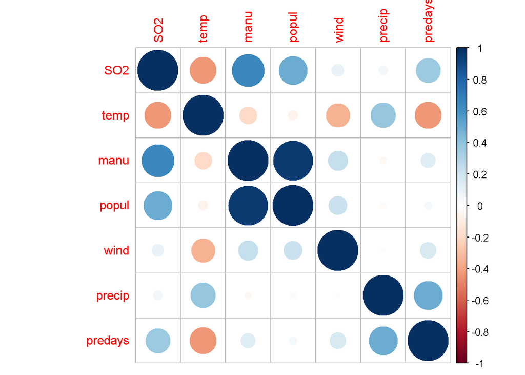

```r
corrplot(cor(us))
```

- There is no missing value in the data.
- From the correlation matrix, we see some significant correlations.
- For ex, there is a positive and strong correlation between manu and popul variables. Also, SO2 and manu has a strong positive correlation. On the other hand, temp and SO2 has a moderate negative correlation with -0.43.

```r
summary(us)
```

```
##       SO2              temp            manu            popul
##  Min.   :  8.00   Min.   :43.50   Min.   :  35.0   Min.   :  71.0
##  1st Qu.: 13.00   1st Qu.:50.60   1st Qu.: 181.0   1st Qu.: 299.0
##  Median : 26.00   Median :54.60   Median : 347.0   Median : 515.0
##  Mean   : 30.05   Mean   :55.76   Mean   : 463.1   Mean   : 608.6
##  3rd Qu.: 35.00   3rd Qu.:59.30   3rd Qu.: 462.0   3rd Qu.: 717.0
##  Max.   :110.00   Max.   :75.50   Max.   :3344.0   Max.   :3369.0
##       wind            precip         predays
##  Min.   : 6.000   Min.   : 7.05   Min.   : 36.0
##  1st Qu.: 8.700   1st Qu.:30.96   1st Qu.:103.0
##  Median : 9.300   Median :38.74   Median :115.0
##  Mean   : 9.444   Mean   :36.77   Mean   :113.9
##  3rd Qu.:10.600   3rd Qu.:43.11   3rd Qu.:128.0
##  Max.   :12.700   Max.   :59.80   Max.   :166.0
```

When we look at the summary statistics, it is seen that average size of cities’ population is approximately 608 thousands. However the maximum population is 3369 thousands in one of the cities. Minimum value of a SO2 content in a city is 8 and the maximum value is 110. Also, it is seen that temperature in the cities has a range from 43.5 Fahrenheit to 75.50 Fahrenheit.

3. Construct a scatterplot matrix of the data and comment on the result

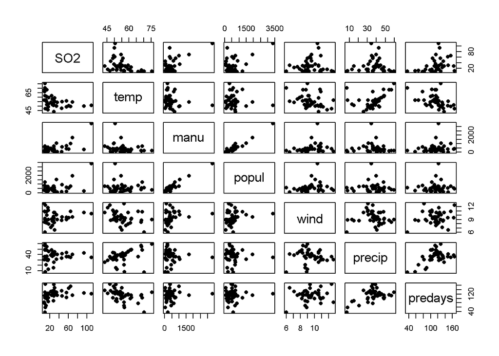

```r
pairs(us,pch=16)
```

- From the output of scatter plot matrix, we see some positive association between some variables visually also.
- For ex, (manu and popul) & (temp and precip) have positive relationship. These results are quite acceptable since we expect that while the population of a city raises, number of manifacturing enterprises also increases due to the industrial reasons.

## “Is there an affect of number of manufacturing enterprises on the SO2 content in a city?”

- Here, the first thing to look at in order to have an idea about that question should be a scatter plot of these variables.

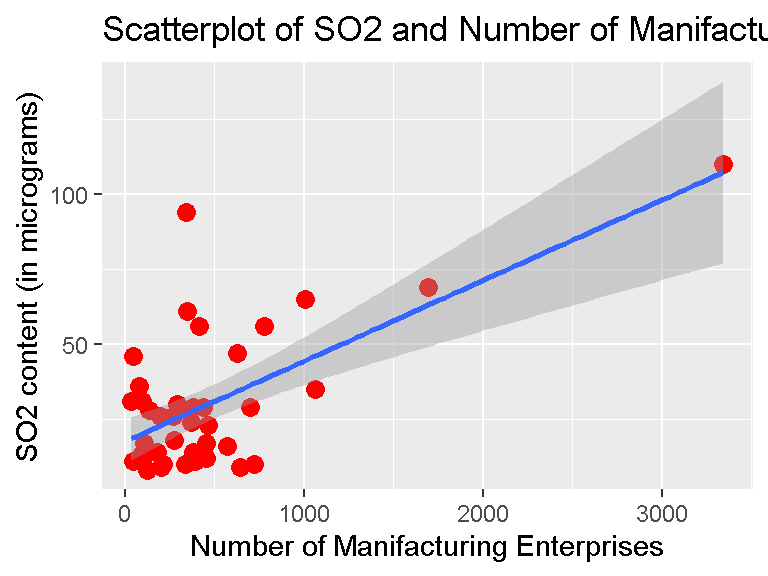

```r
ggplot(data=us, aes(y=SO2,x=manu)) + geom_point(colour = "red", size = 3) +  geom_smooth(method=lm) + ggtitle("Scatterplot of SO2 and Number of Manifacturing Enterprises") + xlab("Number of Manifacturing Enterprises") + ylab("SO2 content (in micrograms)")
```

- From the previous part, we know that correlation between these two variables are approximately 0.6.
- After looking at the scatter plot, we see that although it seems to have a positive relationship, we do not see a clear relationship since most of the observations lie between 0-1000 range for the manu axis. Thus, there may be outliers ,which are seen from the plot as well, affecting this relationship.
- Let’s look at these outliers:

```r
sub<-us[,c("SO2", "manu")]
head(sub)
```

|  | SO2 | manu |
| --- | --- | --- |
| Albany | 46 | 44 |
| Albuquerque | 11 | 46 |
| Atlanta | 24 | 368 |
| Baltimore | 47 | 625 |
| Buffalo | 11 | 391 |
| Charleston | 31 | 35 |

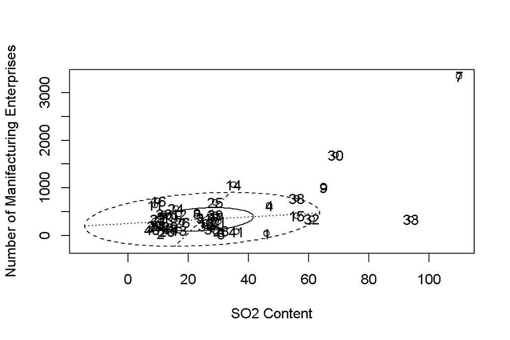

```r
bvbox(sub,xlab = "SO2 Content", ylab ="Number of Manifacturing Enterprises")
text(sub$SO2, sub$manu)
```

- As seen from the output, there are 4 outliers that may affect this relationship.
- We may be remove these observations or maybe replace their value with the median value.

e )

Now, we should draw bivariate boxplot for all of the variables pair by pair.

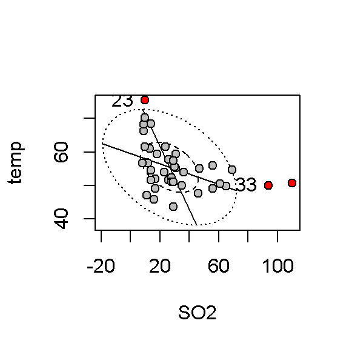

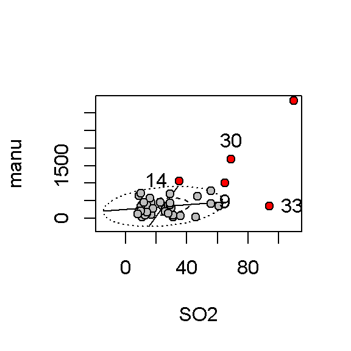

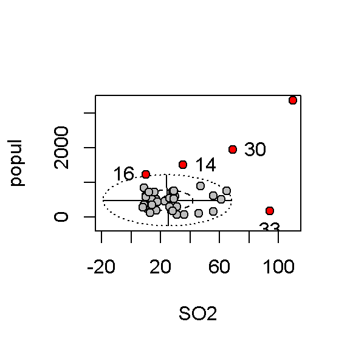

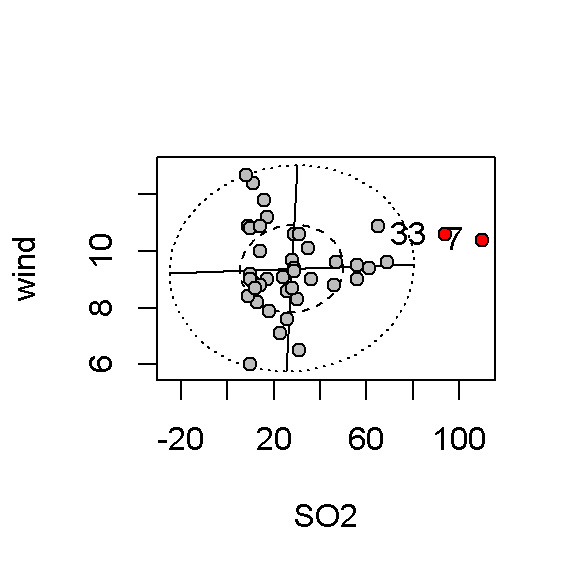

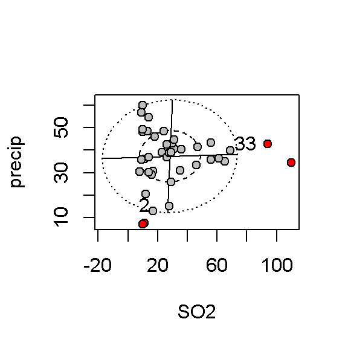

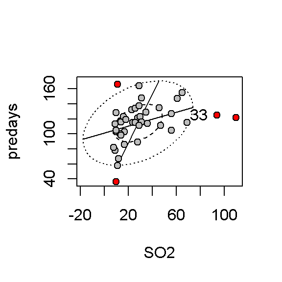

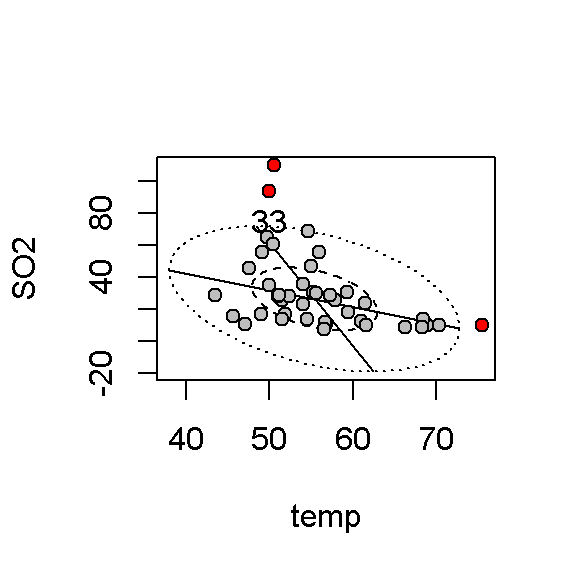

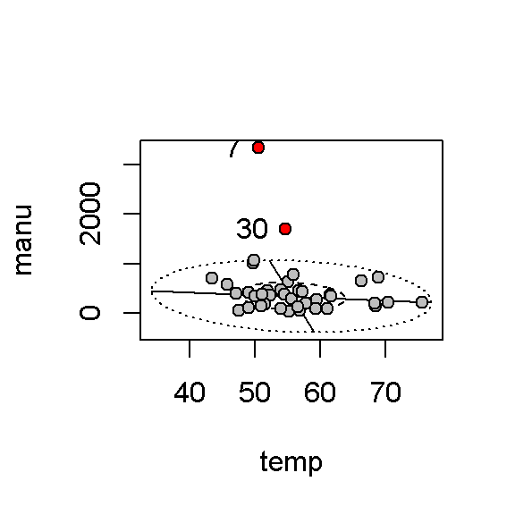

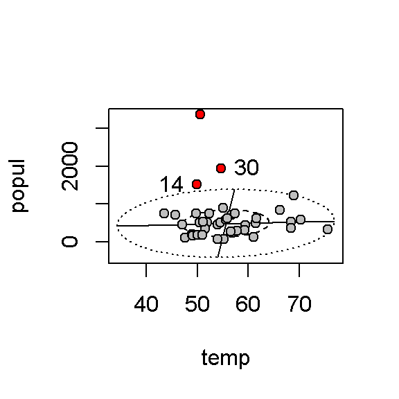

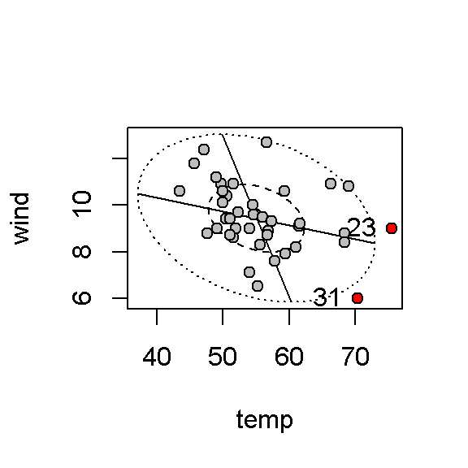

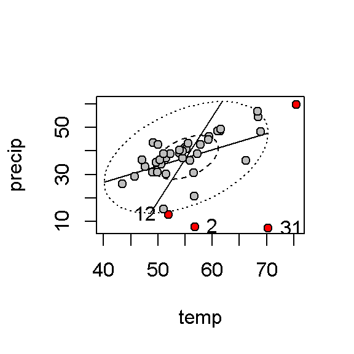

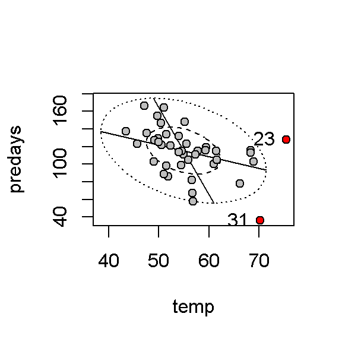

[30 more figures not shown]

```r
for(i in 1:ncol(us)) {
  for(j in 1:ncol(us)) {
    if(i!=j){
      bv.boxplot(us[,i],us[,j], xlab = names(us[i]),ylab = names(us[j]),robust=TRUE,
                 bg.out = 'red',ID.out = TRUE,cex.ID.out = TRUE)


    }


  }

}
```

- (Here, it should be noted that bv.boxplot function is used and robust=True is arranged so that robust estimators are used.)
- Outliers are represented as red points.
- As seen, there are some outliers in some of the bivariate boxplot pairs. For example,
- Precipitation and Predays has 3 outliers.
- Precipitation and Population have also 3 outliers.
- Also, SO2 and Population variables have 5 outliers.
- We will remove 7th, 30th, 14h, 33rd,9th,23rd and 16th observations manually since they are the most common ones in the bivariate boxplots.

```r
#Identifying and removing the outliers
us_withoutoutlier <- us[-c(7,30,14,33,16,9,23),]
dim(us_withoutoutlier)
```

```
## [1] 34  7
```

Now, we have a data of 34 observations.

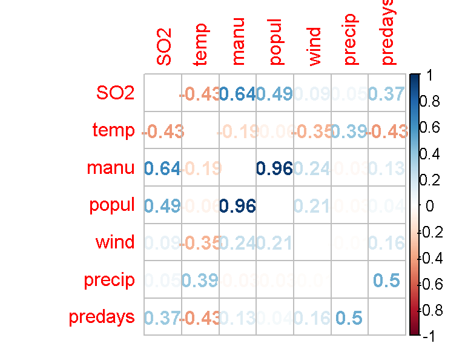

```r
#Correlations between the variables in the original data

corrplot(cor(us),method = "number",diag = FALSE,type = 'full')
```

- As interpreted above, some variables have high correlation such as 0.96, which is the correlation between Manu and Population.
- There are also other high positive correlations exist. Manu & SO2, Popul& SO2 are moderately high correlations as well. However, as it is investigated above by bivariate boxplots, there exists outliers in these pairs. Thus, it could be a good idea to remove these and check the correlations again.
- After removing the outliers, the following correlation matrix is obtained:

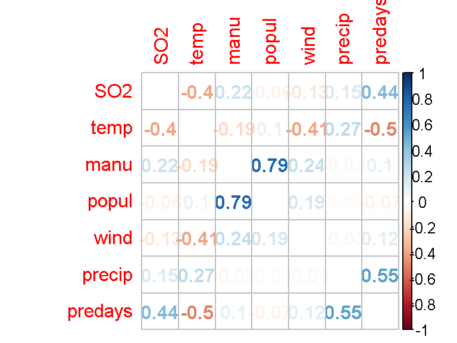

```r
#Correlations between the pairs in the outliers-removed version of the data
corrplot(cor(us_withoutoutlier),method = "number",diag = FALSE,type = 'full')
```

-Let’s compare the other correlation matrix and this one side by side since it is easier. What has changed?

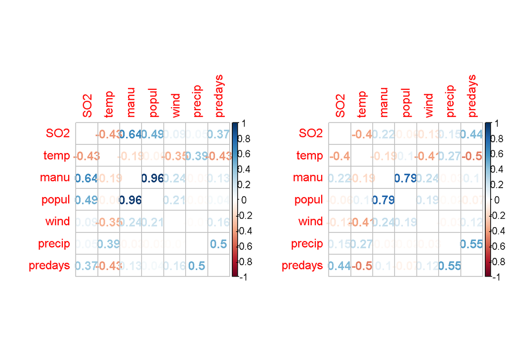

```r
par(mfrow=c(1,2))
corrplot(cor(us),method = "number",diag = FALSE,type = 'full')
corrplot(cor(us_withoutoutlier),method = "number", diag = FALSE,type = 'full')
```

- When the outliers are removed,the correlation between Predays and SO2 has increased to 0.44.
- Also, it is seen that correlation between Temperature and Predays has decreased to -0.5 which is an indication of negative strong relationship.
- On the contrary, the correlation between the Population and Manu has decreased to 0.79.
- However, some logical high correlations have disappeared when we removed the outliers. For example, it is expected that Population and SO2 content should have a high correlation,0.49, as in the first correlation plot. When outliers are removed, its correlation has become insignificant. This is probably due to the lower sample size.
- It is quite problematic since total number of observation is quite low, 34.If there were more cities to examine, it would be better to understand the relationship between these variables to understand the air pollution.

Here, the following research question is the main interest: ## “Do the data holds the asssumption of multivariate normality?”

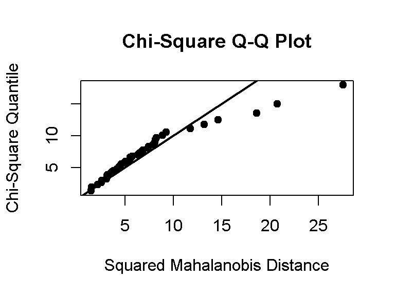

```
## $multivariateNormality
##              Test        Statistic              p value Result
## 1 Mardia Skewness 226.612731693166 4.82491336101959e-15     NO
## 2 Mardia Kurtosis 3.97754689564216 6.96298933924311e-05     NO
## 3             MVN             <NA>                 <NA>     NO
##
## $univariateNormality
##           Test  Variable Statistic   p value Normality
## 1 Shapiro-Wilk    SO2       0.8117  <0.001      NO
## 2 Shapiro-Wilk   temp       0.9355  0.0221      NO
## 3 Shapiro-Wilk   manu       0.6055  <0.001      NO
## 4 Shapiro-Wilk   popul      0.6805  <0.001      NO
## 5 Shapiro-Wilk   wind       0.9806  0.6973      YES
## 6 Shapiro-Wilk  precip      0.9421  0.0373      NO
## 7 Shapiro-Wilk  predays     0.9654  0.2419      YES
##
## $Descriptives
##          n       Mean    Std.Dev Median   Min    Max   25th   75th         Skew
## SO2     41  30.048780  23.472272  26.00  8.00  110.0  13.00  35.00  1.584112608
## temp    41  55.763415   7.227716  54.60 43.50   75.5  50.60  59.30  0.822975684
## manu    41 463.097561 563.473948 347.00 35.00 3344.0 181.00 462.00  3.484603302
## popul   41 608.609756 579.113023 515.00 71.00 3369.0 299.00 717.00  2.941257977
## wind    41   9.443902   1.428644   9.30  6.00   12.7   8.70  10.60  0.002675131
## precip  41  36.769024  11.771550  38.74  7.05   59.8  30.96  43.11 -0.692518149
## predays 41 113.902439  26.506419 115.00 36.00  166.0 103.00 128.00 -0.550092270
##            Kurtosis
## SO2      2.25541093
## temp     0.09066032
## manu    14.33200058
## popul   10.57605759
## wind     0.06015407
## precip   0.49578021
## predays  0.72033969
```

```r
mvn(us,multivariatePlot= "qq")
```

$$H_0: The\ data\ follows\ normal\ distribution.\$$
$$H_1: The\ data\ does \ not\ follow\ a\ normal\ distribution.\$$

```r
 mvn(data = us, mvnTest = "hz")
```

```
## $multivariateNormality
##            Test       HZ      p value MVN
## 1 Henze-Zirkler 1.197216 2.819996e-10  NO
##
## $univariateNormality
##           Test  Variable Statistic   p value Normality
## 1 Shapiro-Wilk    SO2       0.8117  <0.001      NO
## 2 Shapiro-Wilk   temp       0.9355  0.0221      NO
## 3 Shapiro-Wilk   manu       0.6055  <0.001      NO
## 4 Shapiro-Wilk   popul      0.6805  <0.001      NO
## 5 Shapiro-Wilk   wind       0.9806  0.6973      YES
## 6 Shapiro-Wilk  precip      0.9421  0.0373      NO
## 7 Shapiro-Wilk  predays     0.9654  0.2419      YES
##
## $Descriptives
##          n       Mean    Std.Dev Median   Min    Max   25th   75th         Skew
## SO2     41  30.048780  23.472272  26.00  8.00  110.0  13.00  35.00  1.584112608
## temp    41  55.763415   7.227716  54.60 43.50   75.5  50.60  59.30  0.822975684
## manu    41 463.097561 563.473948 347.00 35.00 3344.0 181.00 462.00  3.484603302
## popul   41 608.609756 579.113023 515.00 71.00 3369.0 299.00 717.00  2.941257977
## wind    41   9.443902   1.428644   9.30  6.00   12.7   8.70  10.60  0.002675131
## precip  41  36.769024  11.771550  38.74  7.05   59.8  30.96  43.11 -0.692518149
## predays 41 113.902439  26.506419 115.00 36.00  166.0 103.00 128.00 -0.550092270
##            Kurtosis
## SO2      2.25541093
## temp     0.09066032
## manu    14.33200058
## popul   10.57605759
## wind     0.06015407
## precip   0.49578021
## predays  0.72033969
```

- Henze-Zirklers MVN test suggests non-normality with a very low p-value. We reject
  $$H_0$$
  Thus, there is enough evidence to conclude that the data is not normal at 95% confidence level.

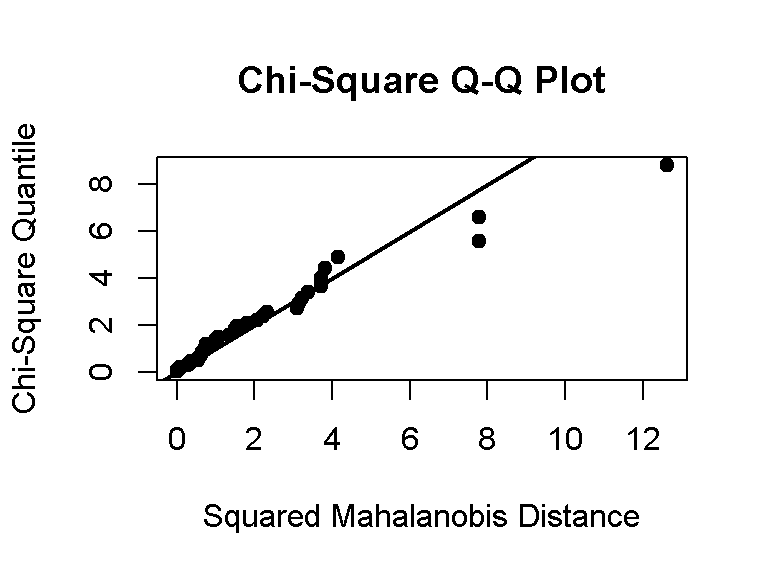

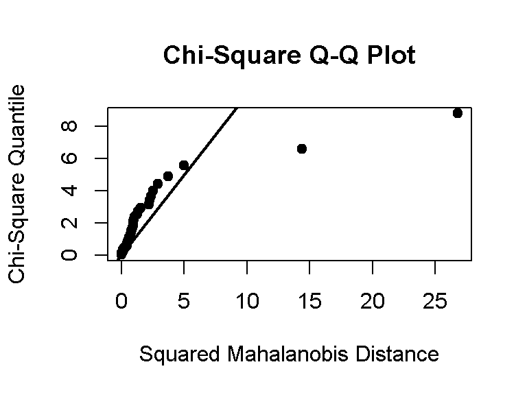

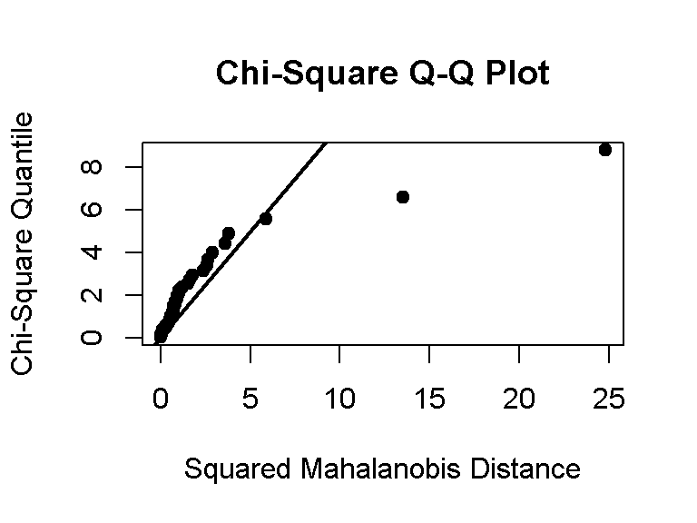

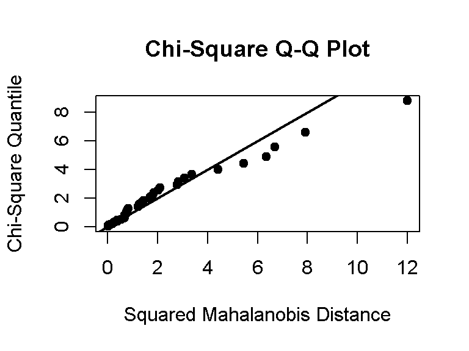

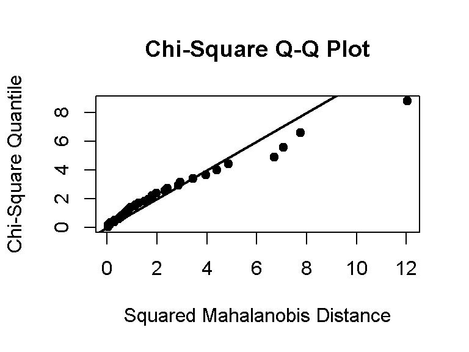

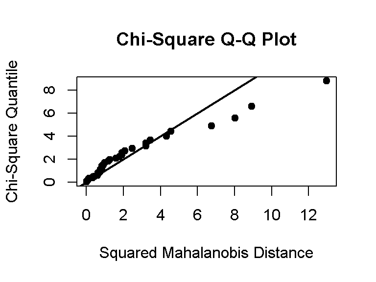

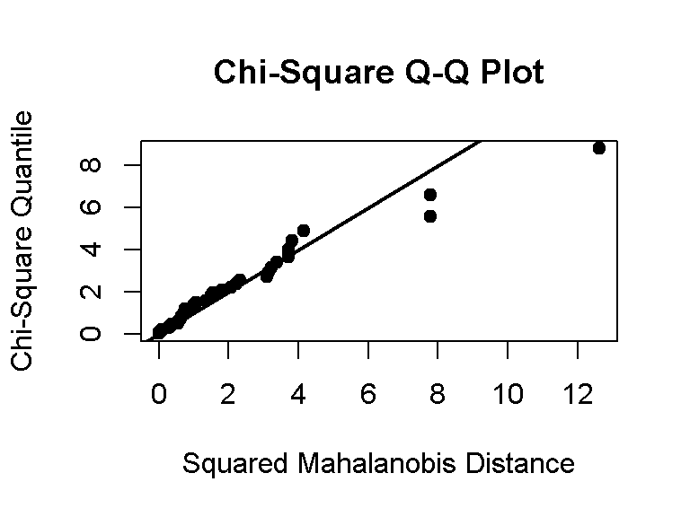

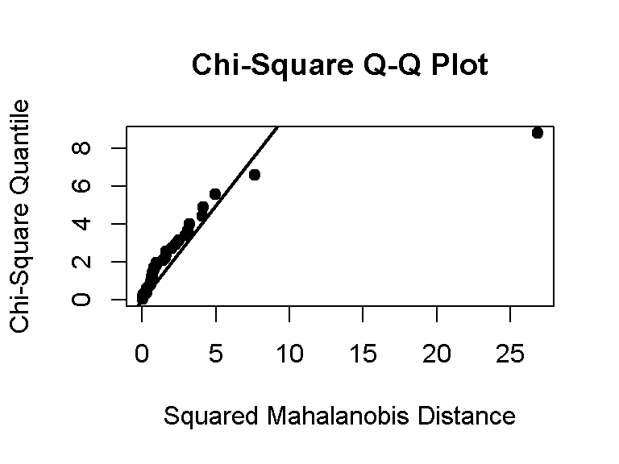

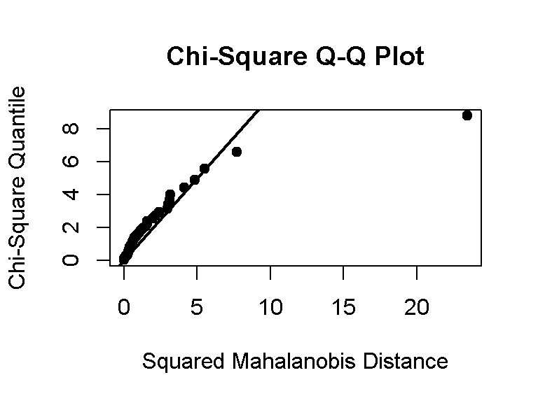

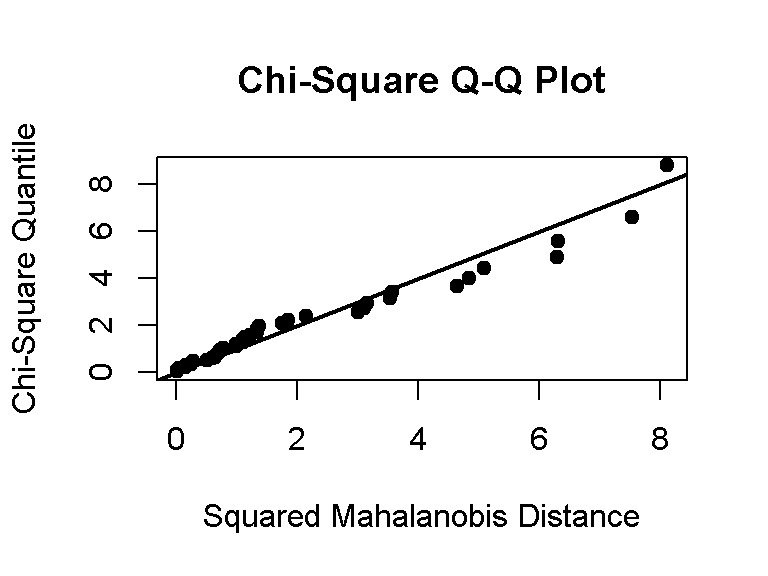

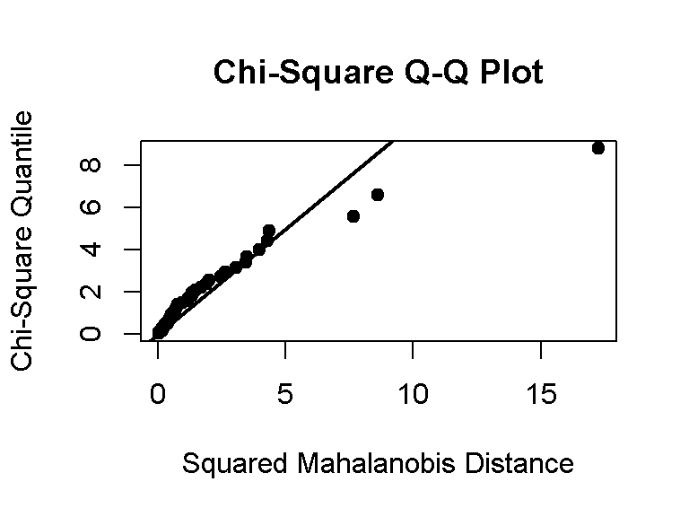

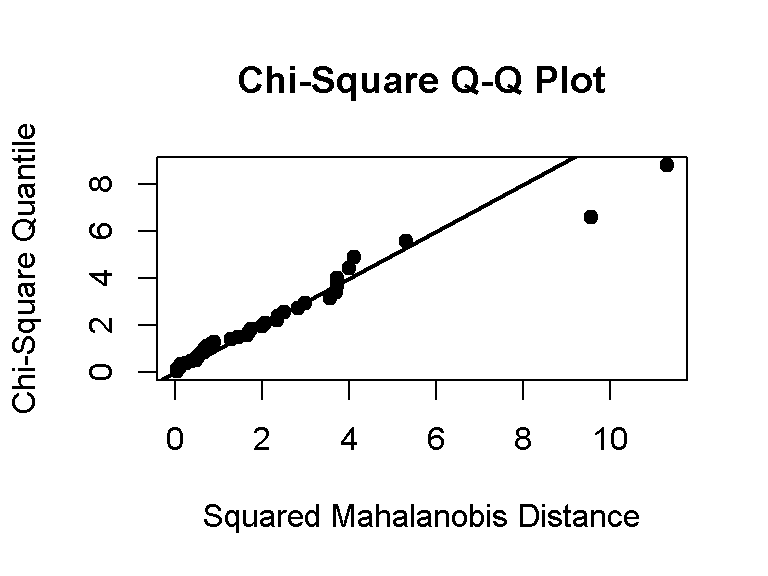

[30 more figures not shown]

```r
for(i in 1:ncol(us)) {
  for(j in 1:ncol(us)) {
    if(i!=j){
      mvn(us[,c(i,j)],multivariatePlot ="qq")[4]
    }
  }
}
```

- From the outputs, we see that some of the QQ-plot seem to be okay. This illustrates that individually, some of the variables are probably follow a normal distribution however when they are combined together, they do not follow a normal distribution.
- Henze-Zirklers MVN test and Multivariate Normality QQ Plot are much more easy to interpret in terms of multivariate situation. It may be quite problematic to check all of the QQ Plot pairs if we would have for ex. 100 different variables. Then it would be impossible to look at all of them one by one.